# Practical Machine Learning Project

Thuy Dao

October 16, 2016

## Background

Using devices such as Jawbone Up, Nike FuelBand, and Fitbit it is now possible to collect a large amount of data about personal activity relatively inexpensively. These type of devices are part of the quantified self movement – a group of enthusiasts who take measurements about themselves regularly to improve their health, to find patterns in their behavior, or because they are tech geeks. One thing that people regularly do is quantify how much of a particular activity they do, but they rarely quantify how well they do it. In this project, your goal will be to use data from accelerometers on the belt, forearm, arm, and dumbell of 6 participants. They were asked to perform barbell lifts correctly and incorrectly in 5 different ways. More information is available from the website here: http://groupware.les.inf.puc-rio.br/har (see the section on the Weight Lifting Exercise Dataset).

## Data Processing

Load the training and testing datasets. All columns with mostly NA, blank, and #DIV/0! should be removed. The user_name, X, timestamp and window columns will also be removed because they will not be used in the models.

```r
library(ggplot2)
library(plyr)
library(caret)
library(randomForest)
library(rattle)
library(rpart)
library(rpart.plot)
setwd("C:/Users/Owner/Documents/Coursera_PracticalMachineLearning/week4/project")
dfTraining <- read.csv("pml-training.csv", na.strings = c("NA", "", "#DIV/0!"))
dfTesting <- read.csv("pml-testing.csv", na.strings = c("NA", ""))

dim(dfTraining)
```

```
## [1] 19622   160
```

```r
dim(dfTesting)
```

```
## [1]  20 160
```

```r
training1 <- dfTraining[ , ! apply( dfTraining , 2 , function(x) any(is.na(x)) ) ]
testing1 <- dfTesting[ , ! apply( dfTesting , 2 , function(x) any(is.na(x)) ) ]

training2 <- training1[, -grep("user_name|^X|timestamp|window", colnames(training1))]
testing2 <- testing1[, -grep("user_name|^X|timestamp|window", colnames(testing1))]

dim(training2)
```

```
## [1] 19622    53
```

```r
dim(testing2)
```

```
## [1] 20 53
```

The training dataset contains 160 variables with 19622 observations, and the testing dataset contains 160 variables with 20 observations to test the performance of prediction of the classification model. After the datasets are cleaned, the training dataset contains 53 variables with 19622 rows, and the testing dataset also contains 53 variables with 20 rows.

## Data Splitting

The training data was splitted up - 70% became the training data, and 30% became the testing data.

```r
set.seed(39523)
inTrain <- createDataPartition(training2$classe, p = 0.7, list = FALSE)
train <- training2[inTrain, ]
test <- training2[-inTrain, ]

dim(train)
```

```
## [1] 13737    53
```

```r
dim(test)
```

```
## [1] 5885   53
```

## Prediction Models

The 10-fold cross validation is used when applying the algorithm.

```r
train_control <- trainControl(method = "cv", number = 10)
```

### Classification Tree

```r
rpart_fit <- train(classe ~ ., data = train, method = "rpart", trControl = train_control)
rpart_fit
```

```
## CART
##
## 13737 samples
##    52 predictor
##     5 classes: 'A', 'B', 'C', 'D', 'E'
##
## No pre-processing
## Resampling: Cross-Validated (10 fold)
## Summary of sample sizes: 12362, 12364, 12361, 12365, 12364, 12363, ...
## Resampling results across tuning parameters:
##
##   cp          Accuracy   Kappa
##   0.03519479  0.5038223  0.35189667
##   0.06028549  0.4164801  0.20933725
##   0.11646831  0.3242598  0.06074325
##
## Accuracy was used to select the optimal model using  the largest value.
## The final value used for the model was cp = 0.03519479.
```

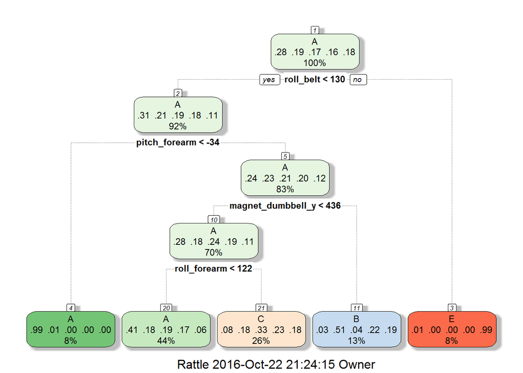

```r
fancyRpartPlot(rpart_fit$finalModel)
```

```r
rpart_predict <- predict(rpart_fit, test)
rpart_result <- confusionMatrix(test$classe, rpart_predict)
rpart_result
```

```
## Confusion Matrix and Statistics
##
##           Reference
## Prediction    A    B    C    D    E
##          A 1514   36  120    0    4
##          B  465  383  291    0    0
##          C  468   33  525    0    0
##          D  413  179  372    0    0
##          E  150  152  304    0  476
##
## Overall Statistics
##
##                Accuracy : 0.4924
##                  95% CI : (0.4796, 0.5053)
##     No Information Rate : 0.5115
##     P-Value [Acc > NIR] : 0.9983
##
##                   Kappa : 0.3374
##  Mcnemar's Test P-Value : NA
##
## Statistics by Class:
##
##                      Class: A Class: B Class: C Class: D Class: E
## Sensitivity            0.5030  0.48914  0.32568       NA  0.99167
## Specificity            0.9443  0.85182  0.88275   0.8362  0.88788
## Pos Pred Value         0.9044  0.33626  0.51170       NA  0.43993
## Neg Pred Value         0.6447  0.91572  0.77629       NA  0.99917
## Prevalence             0.5115  0.13305  0.27392   0.0000  0.08156
## Detection Rate         0.2573  0.06508  0.08921   0.0000  0.08088
## Detection Prevalence   0.2845  0.19354  0.17434   0.1638  0.18386
## Balanced Accuracy      0.7237  0.67048  0.60422       NA  0.93977
```

The classification tree model accuracy rate is around 49%.

### Random Forest

```r
rf_fit <- train(classe ~ ., data = train, method = "rf", trControl = train_control)
rf_fit
```

```
## Random Forest
##
## 13737 samples
##    52 predictor
##     5 classes: 'A', 'B', 'C', 'D', 'E'
##
## No pre-processing
## Resampling: Cross-Validated (10 fold)
## Summary of sample sizes: 12362, 12362, 12363, 12363, 12364, 12363, ...
## Resampling results across tuning parameters:
##
##   mtry  Accuracy   Kappa
##    2    0.9917742  0.9895935
##   27    0.9914100  0.9891336
##   52    0.9820926  0.9773463
##
## Accuracy was used to select the optimal model using  the largest value.
## The final value used for the model was mtry = 2.
```

```r
rf_predict <- predict(rf_fit, test)
rf_result <- confusionMatrix(test$classe, rf_predict)
rf_result
```

```
## Confusion Matrix and Statistics
##
##           Reference
## Prediction    A    B    C    D    E
##          A 1674    0    0    0    0
##          B    4 1131    4    0    0
##          C    0    7 1018    1    0
##          D    0    0   19  945    0
##          E    0    0    0    2 1080
##
## Overall Statistics
##
##                Accuracy : 0.9937
##                  95% CI : (0.9913, 0.9956)
##     No Information Rate : 0.2851
##     P-Value [Acc > NIR] : < 2.2e-16
##
##                   Kappa : 0.992
##  Mcnemar's Test P-Value : NA
##
## Statistics by Class:
##
##                      Class: A Class: B Class: C Class: D Class: E
## Sensitivity            0.9976   0.9938   0.9779   0.9968   1.0000
## Specificity            1.0000   0.9983   0.9983   0.9962   0.9996
## Pos Pred Value         1.0000   0.9930   0.9922   0.9803   0.9982
## Neg Pred Value         0.9991   0.9985   0.9953   0.9994   1.0000
## Prevalence             0.2851   0.1934   0.1769   0.1611   0.1835
## Detection Rate         0.2845   0.1922   0.1730   0.1606   0.1835
## Detection Prevalence   0.2845   0.1935   0.1743   0.1638   0.1839
## Balanced Accuracy      0.9988   0.9961   0.9881   0.9965   0.9998
```

## Out of sample error

```r
outOfSampleError_accuracy <- sum(rf_predict == test$classe)/length(rf_predict)
outOfSampleError_accuracy
```

```
## [1] 0.9937128
```

```r
outOfSampleError <- 1 - outOfSampleError_accuracy
outOfSampleError
```

```
## [1] 0.006287171
```

```r
paste0("Out of sample error estimation: ", round(outOfSampleError*100, digits = 2), "%")
```

```
## [1] "Out of sample error estimation: 0.63%"
```

The random forest model has accuracy rate of 99% and out of sample error of 0.63%. The random forest method is better than classification tree method

### Test Data

The random forest model is applied to the original test data set to answer the quiz questions.

```r
rfTest_predict <- predict(rf_fit, testing2, type = "raw")
rfTest_predict
```

```
##  [1] B A B A A E D B A A B C B A E E A B B B
## Levels: A B C D E
```